# Atividade 1

José Felipe-200053507

2023-05-04

```r
pacman::p_load(tidyverse)
### Gerando dados "observados"
set.seed(1.2023)
m.obs<-100000
dados<-tibble(x1.obs=runif(m.obs, -3, 3),
                x2.obs=runif(m.obs, -3, 3)) %>%
  mutate(mu=abs(x1.obs^3 - 30*sin(x2.obs) + 10),
         y=rnorm(m.obs, mean=mu, sd=1))
```

**a)** Crie uma função computacional para calcular o valor previso da variável resposta $\hat{y}=f(\x; \theta)$ em função de $\x$ e $\theta$. Use a função para calcular $\hat{y}$ para $\theta=(0.1, \ldots, 0.1)$ e $\x=(1, 1)$. Dica: veja o Algoritmo 6.3 do livro Deep Learning.

```r
phi<-function(x) {
  return(1 / (1 + exp(-x)))
}

predict_y<-function(x, theta) {
  w1<-theta[1]
  w2<-theta[2]
  w3 <-theta[3]
  w4 <-theta[4]
  w5 <-theta[5]
  w6 <-theta[6]
  b1 <-theta[7]
  b2 <-theta[8]
  b3 <-theta[9]

  a1 <-x[1] * w1 + x[2] * w3 + b1
  a2 <-x[1] * w2 + x[2] * w4 + b2

  h1 <-phi(a1)
  h2 <-phi(a2)

  y_pred <-h1 * w5 + h2 * w6 + b3

  return(y_pred)
}

# Calculando o valor previsto para theta = (0.1, ..., 0.1) e x = (1, 1)
theta <-rep(0.1, 9)
x <-c(1, 1)

(y_pred <-predict_y(x, theta))
```

```
## [1] 0.2148885
```

**b)** Crie uma rotina computacional para calcular a função de custo $J(\theta)$. Em seguida, divida o conjunto de dados observados de modo que as **primeiras** 80.000 amostras componham o banco de **treinamento** e as **últimas** 20.000 o de **teste**. Qual é o custo da rede **no banco de teste** quando $\theta=(0.1, \ldots, 0.1)$?

```r
##22s
# Função para cálculo do custo J(θ)
f_cost<-function(theta, x, y) {
  # Calcula ŷ para todos os valores de x
  y_pred<-apply(x, 1, predict_y, theta=theta)

  # Calcula o custo
  cost<-mean((y - y_pred)^2)

  return(cost)
}
dados_train<-dados[1:80000, ]
dados_test<-dados[80001:100000, ]

# Variáveis x e y
x_train<-as.matrix(dados_train[, 1:2])
x_test<-as.matrix(dados_test[, 1:2])
y_train<-dados_train$y
y_test<-dados_test$y

# Vetor de parâmetros theta
theta<-rep(0.1, 9)


startTime<-Sys.time()
# Custo da rede no banco de teste para theta = (0.1, ..., 0.1)
cost_test<-f_cost(theta, x_test, y_test)
end_time<-Sys.time()
print(cost_test)
```

```
## [1] 659.6568
```

```r
end_time -startTime
```

```
## Time difference of 0.4673548 secs
```

**c)** Use a regra da cadeia para encontrar expressões algébricas para o vetor gradiente
$$\nabla_\theta J(\theta) = \left(\frac{\partial J}{\partial w_1},
\ldots, \frac{\partial J}{\partial b_3} \right).$$

$$\begin{align*}
\frac{\partial J}{\partial w_1} \&= \frac{\partial J}{\partial
\hat{y}} \cdot \frac{\partial \hat{y}}{\partial h_1} \cdot
\frac{\partial h_1}{\partial a_1} \cdot \frac{\partial a_1}{\partial
w_1} \
\&= -2(y - \hat{y}) \cdot w_5 \cdot \phi'(a_1) \cdot x_1
\end{align*}$$

$$\begin{align*}
\frac{\partial J}{\partial w_2} \&= \frac{\partial J}{\partial
\hat{y}} \cdot \frac{\partial \hat{y}}{\partial h_2} \cdot
\frac{\partial h_2}{\partial a_2} \cdot \frac{\partial a_2}{\partial
w_2} \
\&= -2(y - \hat{y}) \cdot w_6 \cdot \phi'(a_2) \cdot x_1
\end{align*}$$

$$\begin{align*}
\frac{\partial J}{\partial w_3} \&= \frac{\partial J}{\partial
\hat{y}} \cdot \frac{\partial \hat{y}}{\partial h_1} \cdot
\frac{\partial h_1}{\partial a_1} \cdot \frac{\partial a_1}{\partial
w_3} \
\&= -2(y - \hat{y}) \cdot w_5 \cdot \phi'(a_1) \cdot x_2
\end{align*}$$
$$\begin{align*}
\frac{\partial J}{\partial w_4} \&= \frac{\partial J}{\partial
\hat{y}} \cdot \frac{\partial \hat{y}}{\partial h_2} \cdot
\frac{\partial h_2}{\partial a_2} \cdot \frac{\partial a_2}{\partial
w_4} \
\&= -2(y - \hat{y}) \cdot w_6 \cdot \phi'(a_2) \cdot x_2
\end{align*}$$
$$\begin{align*}
\frac{\partial J}{\partial w_5} \&= \frac{\partial J}{\partial
\hat{y}} \cdot \frac{\partial \hat{y}}{\partial w_5} \
\&= -2(y - \hat{y}) \cdot \phi(h_1)
\end{align*}$$

$$\begin{align*}
\frac{\partial J}{\partial w_6} \&= \frac{\partial J}{\partial
\hat{y}} \cdot \frac{\partial \hat{y}}{\partial w_6} \
\&= -2(y - \hat{y}) \cdot \phi(h_2)
\end{align*}$$
$$\begin{align*}
\frac{\partial J}{\partial b_1} \&= \frac{\partial J}{\partial
\hat{y}} \cdot \frac{\partial \hat{y}}{\partial h_1} \cdot
\frac{\partial h_1}{\partial a_1} \cdot \frac{\partial a_1}{\partial
b_1} \
\&= -2(y - \hat{y}) \cdot w_5 \cdot \phi'(a_1)
\end{align*}$$
Continuando a partir de onde paramos, temos:

$$\frac{\partial J}{\partial b_2} = \frac{\partial J}{\partial \hat{y}}
\cdot \frac{\partial \hat{y}}{\partial h_2} \cdot \frac{\partial
h_2}{\partial a_2} \cdot \frac{\partial a_2}{\partial b_2} = -2(y -
\hat{y}) \cdot w_6 \cdot \phi'(a_2)$$

$$\frac{\partial J}{\partial b_3} = \frac{\partial J}{\partial \hat{y}}
\cdot \frac{\partial \hat{y}}{\partial b_3} = -2(y - \hat{y})$$

Assim, o vetor gradiente é:

$$\nabla_\theta J(\theta) = \left(\frac{\partial J}{\partial w_1},
\frac{\partial J}{\partial w_2}, \frac{\partial J}{\partial w_3},
\frac{\partial J}{\partial w_4}, \frac{\partial J}{\partial w_5},
\frac{\partial J}{\partial w_6}, \frac{\partial J}{\partial b_1},
\frac{\partial J}{\partial b_2}, \frac{\partial J}{\partial b_3} \right)$$

Substituindo as expressões obtidas anteriormente, temos:

$$\nabla_\theta J(\theta) = \left(-2(y - \hat{y}) \cdot w_5 \cdot
\phi'(a_1) \cdot x_1, -2(y - \hat{y}) \cdot w_6 \cdot \phi'(a_2)
\cdot x_1, -2(y - \hat{y}) \cdot w_5 \cdot \phi'(a_1) \cdot x_2,
-2(y - \hat{y}) \cdot w_6 \cdot \phi'(a_2) \cdot x_2, -2(y -
\hat{y}) \cdot \phi(h_1), -2(y - \hat{y}) \cdot \phi(h_2), -2(y -
\hat{y}) \cdot w_5 \cdot \phi'(a_1), -2(y - \hat{y}) \cdot w_6 \cdot
\phi'(a_2), -2(y - \hat{y}) \right)$$

**d)** Crie uma função computacional que receba como entrada o vetor $\theta$, uma matrix design ($x$) e as respectivas observações ($y$) e forneça, como saída, o gradiente definido no item c). Apresente o resultado da função aplicada sobre o **banco de treinamento**, quando $\theta=(0.1, \ldots, 0.1)$. Atenção: implemente o algoritmo *back-propagation* (Algoritmo 6.4 do livro Deep Learning) para evitar realizar a mesma operação múltiplas vezes.

```r
sigmoid<-function(x) {
  return(1 / (1 + exp(-x)))
}

sigmoid_derivative<-function(x) {
  s<-sigmoid(x)
  return(s * (1 - s))
}


gradient<-function(theta, x, y) {
  m<-nrow(x)  # número de observações
  n<-ncol(x)  # número de features

  # Desempacotando os parâmetros
  w1<-theta[1]
  w2<-theta[2]
  w3<-theta[3]
  w4<-theta[4]
  w5<-theta[5]
  w6<-theta[6]
  b1<-theta[7]
  b2<-theta[8]
  b3<-theta[9]

  # Inicializando o vetor gradiente
  grad<-rep(0, length(theta))

  for (i in 1:m) {
    # Propagação direta
    a1<-x[i, 1] * w1 + x[i, 2] * w3 + b1
    h1<-sigmoid(a1)
    a2<-x[i, 1] * w2 + x[i, 2] * w4 + b2
    h2<-sigmoid(a2)
    y_hat<-h1 * w5 + h2 * w6 + b3

    # Cálculo do erro
    delta<-y_hat - y[i]

    # Cálculo do gradiente
    grad[1]<-grad[1] - 2 * delta * w5 * sigmoid_derivative(a1) * x[i, 1]
    grad[2]<-grad[2] - 2 * delta * w6 * sigmoid_derivative(a2) * x[i, 1]
    grad[3]<-grad[3] - 2 * delta * w5 * sigmoid_derivative(a1) * x[i, 2]
    grad[4]<-grad[4] - 2 * delta * w6 * sigmoid_derivative(a2) * x[i, 2]
    grad[5]<-grad[5] - 2 * delta * sigmoid(h1)
    grad[6]<-grad[6] - 2 * delta * sigmoid(h2)
    grad[7]<-grad[7] - 2 * delta * w5 * sigmoid_derivative(a1)
    grad[8]<-grad[8] - 2 * delta * w6 * sigmoid_derivative(a2)
    grad[9]<-grad[9] - 2 * delta
  }

  # Dividindo o gradiente pelo número de observações
  grad<-grad / m

  return(-grad)
}

theta<-rep(0.1, 9)  # θ = (0.1, ..., 0.1)
teste<-gradient(theta, x_train, y_train)
print(teste)
```

```
## [1]  -0.1767887  -0.1767887   0.6458047   0.6458047 -27.1637232 -27.1637232
## [7]  -1.0732662  -1.0732662 -43.4113383
```

**e)** Aplique o método do gradiente para encontrar os parâmetros que minimizam a função de custo no banco de teste. Inicie o algoritmo no ponto $\theta=(0, \ldots, 0)$, use taxa de aprendizagem $\epsilon=0.1$ e rode o algoritmo por 100 iterações. Reporte o menor custo obtido e indique em qual iteração ele foi observado. Apresente também o vetor de pesos estimado e comente o resultado.

```r
theta<-rep(0, 9)  # θ = (0, ..., 0)
learning_rate<-0.1
num_iterations<-100

# Vetor para armazenar os valores do custo em cada iteração
cost_history<-numeric(num_iterations)

# Gradiente descendente
for (iteration in 1:num_iterations) {
  # Calcular o gradiente
  grad<-gradient(theta, x_train, y_train)

  # Atualizar os parâmetros usando o gradiente
  theta<-theta - learning_rate * grad

  # Calcular o custo atual
  cost<-f_cost(theta, x_train, y_train)
  cost_history[iteration]<-cost
}

# Encontrar o menor custo e a iteração correspondente
min_cost<-min(cost_history)
min_iteration<-which.min(cost_history)

# Vetor de pesos estimado
estimated_weights<-theta

# Imprimir os resultados
cat("Menor custo obtido:", min_cost, "\n")
```

```
## Menor custo obtido: 144.7887
```

```r
cat("Iteração do menor custo:", min_iteration, "\n")
```

```
## Iteração do menor custo: 32
```

```r
cat("Vetor de pesos estimado:", estimated_weights, "\n")
```

```
## Vetor de pesos estimado: -1.408768 -1.408768 -2.501462 -2.501462 8.412583 8.412583 2.734511 2.734511 10.61034
```

**f)** Apresente o gráfico do custo no conjunto de treinamento e no de teste (uma linha para cada) em função do número da interação do processo de otimização. Comente os resultados.

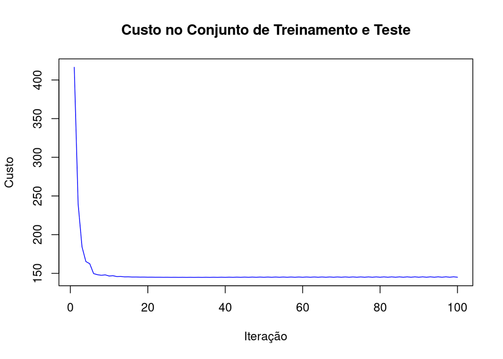

```r
plot(1:num_iterations, cost_history, type = "l", col = "blue", xlab = "Iteração", ylab = "Custo", main = "Custo no Conjunto de Treinamento e Teste")# Plotando o gráfico do custo
```

**g)** Calcule os valores previstos ($\hat{y}_i$) e os resíduos ($y_i-\hat{y}_i$) da rede no conjunto de teste e represente-os graficamente em função de $x_1$ e $x_2$. Dica: tome como base o código usado para a visualização da superfície $(E(Y|X_1, X_2), X_1, X_2)$. Altere o gradiente de cores e, se necessário, use pontos semi-transparentes. Analise o desempenho da rede nas diferentes regiões do plano. Há locais onde o modelo é claramente viesado ou menos acurado?

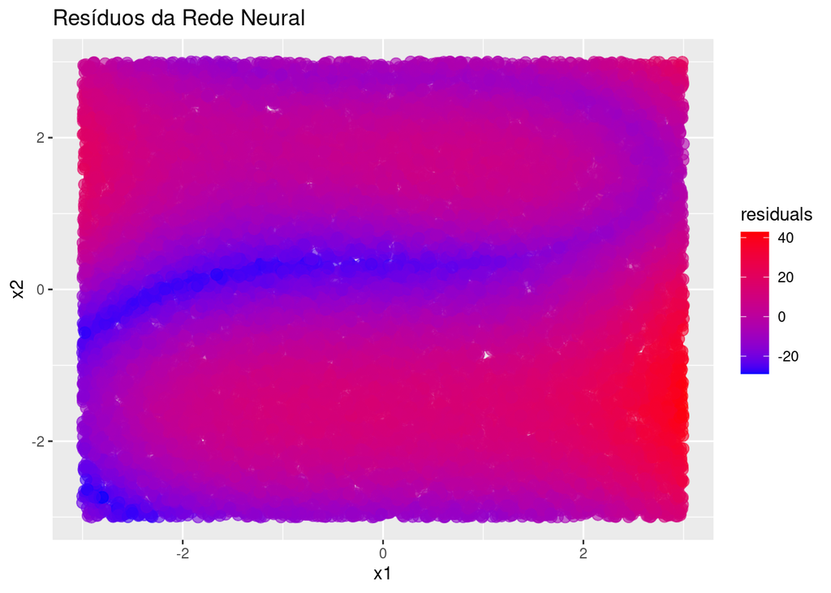

```r
# Calcular os valores previstos no conjunto de teste
y_pred<-apply(x_test, 1, function(x) predict_y(x, estimated_weights))

# Calcular os resíduos
residuals<-y_test - y_pred


# Converter os valores dos resíduos para o intervalo [0, 1]
residuals_scaled<-(residuals - min(residuals)) / (max(residuals) - min(residuals))


residuals_df<-data.frame(x1 = x_test[, 1], x2 = x_test[, 2], residuals = residuals)
require(ggplot2)
ggplot(residuals_df, aes(x = x1, y = x2, color = residuals)) +
  geom_point(size = 3, alpha = 0.6) +
  labs(title = "Resíduos da Rede Neural", x = "x1", y = "x2") +
  scale_color_gradient(low = "blue", high = "red")
```

**h)** Faça um gráfico do valor observado ($y_i$) em função do valor esperado ($\hat{y}_i=E(Y_i|x_{1i}, x_{2i})$) para cada observação do conjunto de teste. Interprete o resultado.

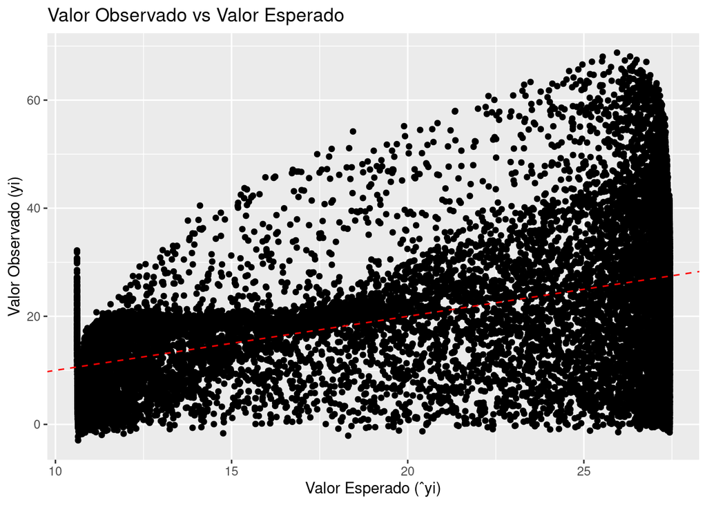

```r
df<-data.frame(y_obs = y_test, y_pred = y_pred)# Criar um dataframe com os valores observados e previstos


ggplot(df, aes(x = y_pred, y = y_obs)) +
  geom_point() +
  geom_abline(intercept = 0, sl= 1, linetype = "dashed", color = "red") +
  labs(x = "Valor Esperado (ˆyi)", y = "Valor Observado (yi)") +
  ggtitle("Valor Observado vs Valor Esperado")
```

**i)** Para cada $k=1, \ldots, 300$, recalcule o gradiente obtido no item d) usando apenas as $k$-primeiras observações do banco de dados original. Novamente, use $\theta=(0.1, \ldots, 0.1)$. Apresente um gráfico com o valor do primeiro elemento do gradiente (isso é, a derivada parcial $\frac{\partial J}{\partial w_1}$) em função do número de amostras $k$. Como referência, adicione uma linha horizontal vermelha indicando o valor obtido em d). Em seguida, use a função `microbenchmark` para comparar o tempo de cálculo do gradiente para $k=300$ e $k=100000$. Explique de que maneira os resultados dessa análise podem ser usados para acelerar a execução do item e).

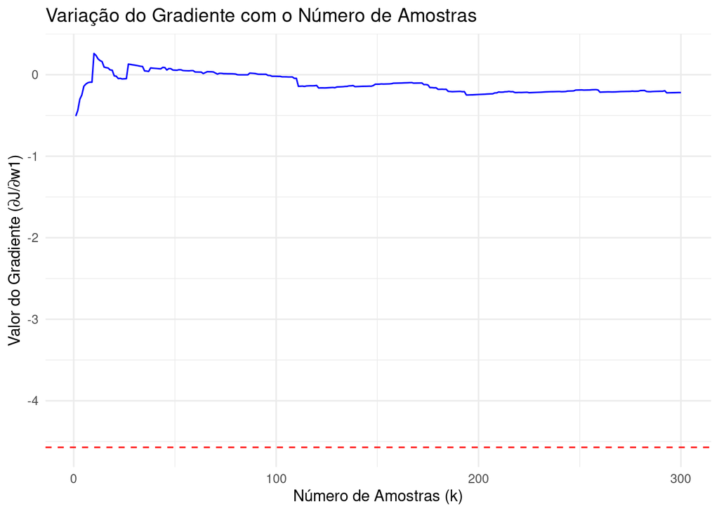

```r
library(microbenchmark)

# Vetor para armazenar os valores do primeiro elemento do gradiente
grad_values<-c()

# Vetor para armazenar os valores de k
k_values<-1:300

# Gradiente original
grad_d<-gradient(theta, x_train, y_train)

# Função para calcular o gradiente com um subconjunto de observações
gradient_subset<-function(theta, x, y, k) {
  grad<-rep(0, length(theta))
  for (i in 1:k) {
    a1<-x[i, 1] * theta[1] + x[i, 2] * theta[3] + theta[7]
    h1<-sigmoid(a1)
    a2<-x[i, 1] * theta[2] + x[i, 2] * theta[4] + theta[8]
    h2<-sigmoid(a2)
    y_hat<-h1 * theta[5] + h2 * theta[6] + theta[9]
    delta3<-y_hat - y[i]
    grad[1]<-grad[1] + delta3 * h1 * sigmoid_derivative(a1) * x[i, 1]
    grad[2]<-grad[2] + delta3 * h2 * sigmoid_derivative(a2) * x[i, 1]
    grad[3]<-grad[3] + delta3 * h1 * sigmoid_derivative(a1) * x[i, 2]
    grad[4]<-grad[4] + delta3 * h2 * sigmoid_derivative(a2) * x[i, 2]
    grad[5]<-grad[5] + delta3 * sigmoid(h1)
    grad[6]<-grad[6] + delta3 * sigmoid(h2)
    grad[7]<-grad[7] + delta3 * sigmoid_derivative(a1)
    grad[8]<-grad[8] + delta3 * sigmoid_derivative(a2)
    grad[9]<-grad[9] + delta3
  }
  grad<-grad / k
  return(grad)
}

# Calcular o gradiente para diferentes valores de k
for (k in k_values) {
  grad_k<-gradient_subset(theta, x_train, y_train, k)
  grad_values<-c(grad_values, grad_k[1])
}

# Data frame com os valores do primeiro elemento do gradiente e o número de amostras k
df<-data.frame(k = k_values, grad = grad_values)

# Plotar o gráfico
ggplot(df, aes(x = k, y = grad)) +
  geom_line(color = "blue") +
  geom_hline(yintercept = grad_d[1], color = "red", linetype = "dashed") +
  labs(x = "Número de Amostras (k)", y = "Valor do Gradiente (∂J/∂w1)") +
  ggtitle("Variação do Gradiente com o Número de Amostras") +
  theme_minimal()
```

```r
time_300<-microbenchmark(gradient_subset(theta, x_train, y_train, 300))# Comparar os tempos de cálculo do gradiente

time_100000<-microbenchmark(gradient_subset(theta, x_train, y_train, 10000))

print(time_300)
```

```
## Unit: milliseconds
##                                           expr      min       lq     mean
##  gradient_subset(theta, x_train, y_train, 300) 4.296341 4.528376 5.149462
##    median       uq      max neval
##  4.734431 5.289966 9.694084   100
```

```r
print(time_100000)
```

```
## Unit: milliseconds
##                                             expr     min       lq     mean
##  gradient_subset(theta, x_train, y_train, 10000) 162.798 167.1206 180.4108
##    median      uq     max neval
##  170.3818 193.335 256.846   100
```

**j)** Ajuste sobre o conjunto de treinamento um modelo linear normal (**modelo linear 1**)
$$Y_i \sim N(\beta_0 + \beta_1 x_{1i} + \beta_2 x_{2i}, \sigma)$$
usando a função `lm` do pacote `R` (ou outra equivalente). Em seguida, inclua na lista de covariáveis termos quadráticos e de interação linear. Isso é, assuma que no **modelo linear 2**,
$$E(Y|x_1, x_2) = \beta_0 + \beta_1 x_1 + \beta_2 x_2 + \beta_3 x_1^2 +
\beta_4 x_2^2 + \beta_5 x_1 x_2.$$
Compare o erro quadrático médio no conjunto de teste dos dois modelos lineares acima com o da rede neural ajustada anteriormente. Qual dos 3 modelos você usaria para previsão? Justifique sua resposta.

```r
train_data<-data.frame(x1 = x_train[,1], x2 = x_train[,2], Y = y_train)# Comparar os tempos de cálculo do gradiente

test_data<-data.frame(x1 = x_test[,1], x2 = x_test[,2], Y = y_test)

# Modelo Linear 1
lm_model1<-lm(Y ~ x1 + x2, data = train_data)

# Modelo Linear 2
lm_model2<-lm(Y ~ x1 + x2 + I(x1^2) + I(x2^2) + I(x1*x2), data = train_data)
# Previsões dos modelos
predictions_model1<-predict(lm_model1, newdata = test_data)
predictions_model2<-predict(lm_model2, newdata = test_data)

# Cálculo do EQM no conjunto de teste para cada modelo
mse_model1<-mean((predictions_model1 - test_data$Y)^2)
mse_model2<-mean((predictions_model2 - test_data$Y)^2)
mse_neural<-mean((y_test - y_pred)^2)

print(paste("EQM Modelo Linear 1:", mse_model1))
```

```
## [1] "EQM Modelo Linear 1: 137.527056694031"
```

```r
print(paste("EQM Modelo Linear 2:", mse_model2))
```

```
## [1] "EQM Modelo Linear 2: 94.0717210914401"
```

```r
print(paste("EQM Rede Neural:", mse_neural))
```

```
## [1] "EQM Rede Neural: 142.425721564796"
```

**k)** Para cada modelo ajustado (os dois lineares e a rede neural), descreva o efeito no valor esperado da variável resposta causado por um aumento de uma unidade da covariável $x_1$?

No Modelo Linear 1, o efeito de um aumento de uma unidade em $x_1$ é representado pelo coeficiente estimado $\beta_1$. Se $\beta_1$ for positivo, significa que um aumento em $x_1$ levará a um aumento no valor esperado da variável resposta $Y$. Da mesma forma, se $\beta_1$ for negativo, um aumento em $x_1$ resultará em uma diminuição no valor esperado de $Y$.

No Modelo Linear 2, além do efeito de $\beta_1$, também temos os efeitos dos termos quadráticos e de interação. O coeficiente $\beta_1$ representa o efeito linear de $x_1$ no valor esperado de $Y$. Os termos quadráticos e de interação ($\beta_3 x_1^2$, $\beta_4 x_2^2$, $\beta_5 x_1 x_2$) capturam efeitos não lineares e de interação entre as covariáveis. Portanto, o efeito de um aumento de uma unidade em $x_1$ no valor esperado de $Y$ depende dos valores estimados para $\beta_1$, $\beta_3$, $\beta_5$, bem como dos valores de $x_2$.

Na rede neural, o efeito de um aumento de uma unidade em $x_1$ é determinado pelos pesos associados à entrada $x_1$ e às conexões com as camadas ocultas e de saída. Como a rede neural é um modelo complexo e não linear, é difícil descrever o efeito de forma direta. O efeito dependerá da arquitetura da rede, dos valores dos pesos e dos padrões de aprendizado identificados durante o treinamento. Portanto, é necessário analisar o impacto em termos das previsões da rede neural para diferentes valores de $x_1$.

**l)** Novamente, para cada um dos 3 modelos em estudo, calcule o percentual de vezes que o intervalo de confiança de 95% (para uma nova observação!) capturou o valor de $y_i$. Considere apenas os dados do conjunto de teste. No caso da rede neural, assuma que, aproximadamente, $\frac{y_i - \hat{y}}{\hat{\sigma}} \sim N(0, 1)$, onde $\hat{\sigma}$ representa a raiz do erro quadrático médio da rede. Comente os resultados. Dica: para os modelos lineares, use a função `predict(mod, interval="prediction")`.

```r
# Calculando as previsões e os intervalos de confiança
predictions_model1<-predict(lm_model1, newdata = test_data, interval = "prediction")

# Verificando se o valor de yi está dentro do intervalo de confiança
capture_rate_model1<-mean(y_test >= predictions_model1[, "lwr"] & y_test <= predictions_model1[, "upr"])



# Calculando as previsões e os intervalos de confiança
predictions_model2<-predict(lm_model2, newdata = test_data, interval = "prediction")

# Verificando se o valor de yi está dentro do intervalo de confiança
capture_rate_model2<-mean(y_test >= predictions_model2[, "lwr"] & y_test <= predictions_model2[, "upr"])


# Calculando os resíduos padronizados
residuals_neural<-(y_test - y_pred) / sqrt(abs( residuals))

# Verificando se o resíduo padronizado está dentro do intervalo de confiança ([-1.96, 1.96])
capture_rate_neural<-mean(residuals_neural >= -1.96 & residuals_neural <= 1.96)
```

**m)** Para o **modelo linear 1**, faça um gráfico de disperção entre $x_1$ e $x_2$, onde cada ponto correponde a uma observação do conjunto de teste. Identifique os pontos que estavam contidos nos respectivos intervalos de confianças utiliizando a cor verde. Para os demais pontos, use vermelho. Comente o resultado.

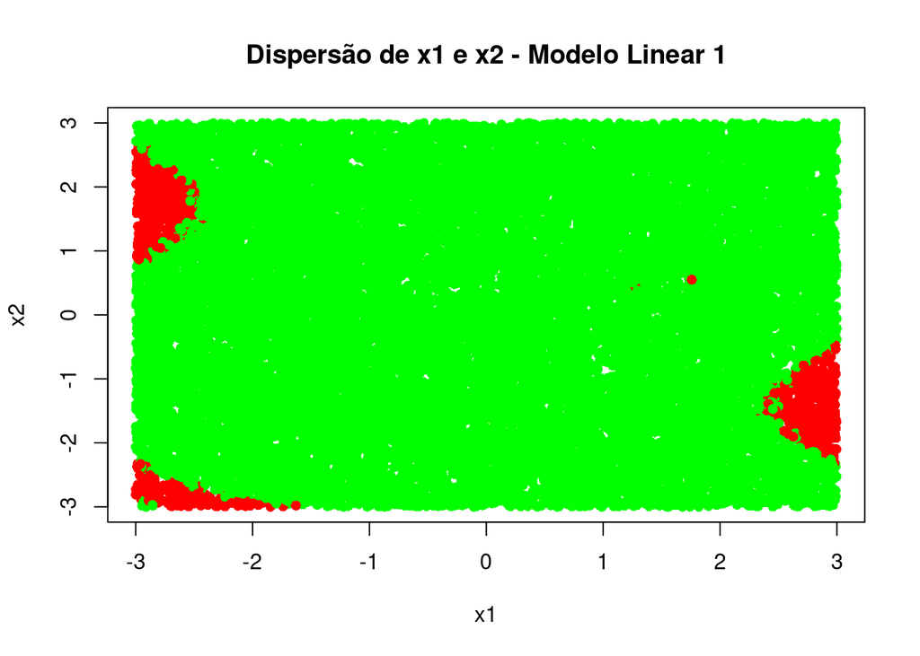

```r
test_data <-data.frame(x1 = x_test[, 1], x2 = x_test[, 2])

# Obter as previsões e os intervalos de confiança para o modelo linear 1
predictions_model1 <-predict(lm_model1, newdata = test_data, interval = "prediction")

lower_bound <-predictions_model1[, "lwr"]# Separar os limites inferior e superior dos intervalos de confiança

upper_bound <-predictions_model1[, "upr"]

#Seleciona as cores
colors <-ifelse(y_test >= lower_bound & y_test <= upper_bound, "green", "red")

# Gráfico
plot(x_test[, 1], x_test[, 2], pch = 16, col = colors,
     main = "Dispersão de x1 e x2 - Modelo Linear 1",
     xlab = "x1", ylab = "x2")
```